# BT1101-Tutorial 5 (Part 2 Deadline: 3 Oct 9am)

## Tutorial 5

### Guideline for rounding off

- Limit rounding off to the final answers. Rounding off in your working steps may reduce accuracy of your final answers.
- If the answer is greater than 1, round off to 2 decimal places.
- If the answer is less than 1, round off to 3 significant numbers.
- When rounding, also take note of the natural rounding points, for example, costs in dollars would round off to 2 decimal places.

**Where necessary, check the distribution for the variables and for the presence of outliers.**

### Preparation

```r
# install required packages if you have not

library("rcompanion") #this package is required for transformTukey function
library("rstatix") # for Welch ANOVA test
library("Rmisc")  # ci function to compute confidence interval
library("rpivotTable")
library("knitr")
library("psych")
library("dplyr")
library("tidyr")
library(wooldridge) # contains the data `smoke`
```

## Tutorial 5 Part 2 (To be submitted - 30 Marks)

Context: Use data(‘smoke’). This is an actual data set with 807 observations on 10 variables. Data is collected from male individuals in 1979 and early 1980 from the Smoking Supplement to the 1979 National Health Interview Survey conducted in US.

The variables are described below:

- `educ`: years of schooling
- `cigpric`: cigarette price (in cents/pack) within the state the individual resides in
- `white`: =1 if race is white; =0 if race is non-white
- `age`: in years
- `income`: annual income, $
- `cigs`: cigarettes smoked per day
- `restaurn`: =1 if restaurants in the individual’s state of residence has smoking restrictions; =0 if no smoking restrictions
- `lincome`: log(income)
- `agesq`: age^2
- `lcigpric`: log(cigprice)

You are tasked to conduct the required analyses to better understand smoking behavior (or cigarette demand) in the US during the period of study. We will consider those who smoke zero cigarette per day to be a non-smoker while those who smoke at least one per day to be a smoker.

```r
data(smoke)
SK<-smoke
```

### Q2.(a) Dashboard for Smokers vs Non-Smokers (4 marks)

- 1. Create a new categorical variable called “smoker” in the dataframe `SK`, to label the observations as “Smoker” or “Non-Smoker”. (1 mark)
- 2. Create a table and piechart for the dashboard to display the frequency distribution of Smoker vs Non-Smoker. (2 marks)
- 3. Label the piechart with an appropriate title, and each slice with “Smoker” or “Non-Smoker” and the percentage of its frequency to overall frequency (e.g. if frequency of “Smoker” is 50 and total frequency of “Smoker” and “Non-Smoker” is 100, then the percentage would be 50% ((50/100)*100%)). Each slice should also be of a different colour. (1 mark)

```r
######i label "smoker" or "non-smoker"
SKi <- SK %>% mutate(smoker = ifelse(cigs==0, "Non-Smoker", "Smoker"))

######ii and iii  table and piecharrt for frequency distibution of smoker vs non-smoker
smoker_freq <- SKi %>% count(smoker)
kable(smoker_freq, caption = "Frequency Distribution of Smoker vs Non-Smoker")
```

Frequency Distribution of Smoker vs Non-Smoker

| smoker | n |
| --- | --- |
| Non-Smoker | 497 |
| Smoker | 310 |

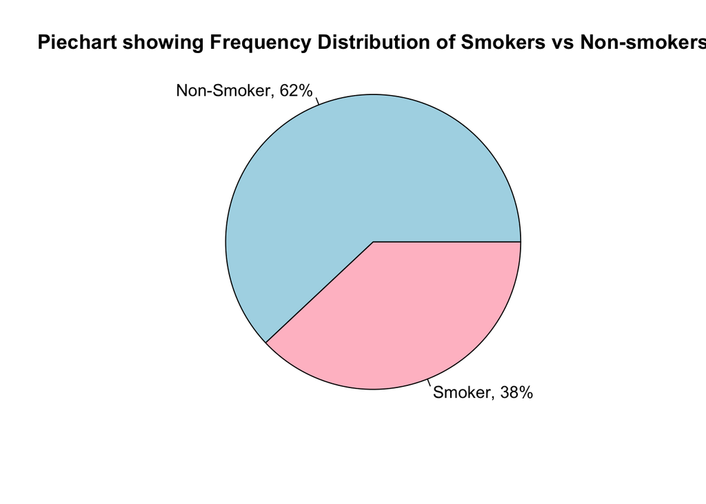

```r
slice.payment <-smoker_freq
smoker.piepercent <- 100*round(smoker_freq$n/sum(smoker_freq$n),2)
label <- smoker_freq$smoker
label <- paste(label, ",", sep = "")
label <- paste(label, smoker.piepercent)
label <- paste (label, "%", sep="")
pie(smoker.piepercent, labels = label, radius = 1, main = "Piechart showing Frequency Distribution of Smokers vs Non-smokers", col = c("light blue", "pink"))
```

**END: YOUR ANSWER**

### Q2.(b) Amongst white individuals, the population proportion that is a smoker is said to be equal to 0.4. Evaluate if this statement is true by conducting a hypothesis test using 5% level of significance. Clearly define H0 and H1 and explain your findings. (4 marks)

```r
SK_white <- SKi %>% filter(white ==1)

###H0: u = 0.4 v.s. H1: u != 0.4 where u represents the population proportion that is a smoker amongst white individuals.--> Conduct test at 5% significance level
SK_white_smoke <- SK_white %>% filter(smoker=='Smoker')
phat <- nrow(SK_white_smoke)/nrow(SK_white)

critical_val <- qnorm(0.025)
critical_val
```

```
## [1] -1.959964
```

```r
#critical value = -1.959964
test_stat <- (phat-0.4)/sqrt(0.4*(1-0.4)/nrow(SK_white))
test_stat
```

```
## [1] -0.8126006
```

```r
#test statistic = -0.8126006

#Does test_stat fall above upper limit?
test_stat > -critical_val
```

```
## [1] FALSE
```

```r
#Does test_stat fall below lower limit?
test_stat < critical_val
```

```
## [1] FALSE
```

```r
p_value<- 2*pt(test_stat, nrow(SK_white))
p_value
```

```
## [1] 0.4167199
```

```r
#Is p-value < 0.05 to reject H0?
p_value < 0.05
```

```
## [1] FALSE
```

For testing using critical value: We do not reject H0 because the test statistic falls outside of the rejection region. Thus, the statement is true. For testing using p-value: We do not reject H0 because p-value is more than 0.025. Thus, the statement is true.

**END: YOUR ANSWER**

### Q2.(c) Dashboard for `cigs` (7 marks)

- 1. Generate a table, with an appropriate title, to display the following descriptive statistics for `cigs`: mean, median, standard deviation, kurtosis, skewness coefficient. (2 marks)
- 2. Plot a histogram for `cigs`. Describe the distribution for `cigs` and explain if there are any outliers (2 marks)
- 3. Develop the 95% confidence interval for mean `cigs`. Based on this confidence interval, explain if you can reasonably conclude that the mean number of cigarettes smoked per day is 10? (3 marks)

** You are not required to remove any outliers detected**

```r
######i cigs - mean, median, sd, kurt, skew
SK.cigs <- round(describe(SK$cigs),2)
SK.cigs <- SK.cigs %>% select(!c(trimmed,mad,range,min,max,se))
SK.cigs$vars <- c("No. of Cigarettes per day")
kable(SK.cigs, row.names=FALSE, caption = "Distribution of Cigs Data")
```

Distribution of Cigs Data

| vars | n | mean | sd | median | skew | kurtosis |
| --- | --- | --- | --- | --- | --- | --- |
| No. of Cigarettes per day | 807 | 8.69 | 13.72 | 0 | 1.65 | 2.4 |

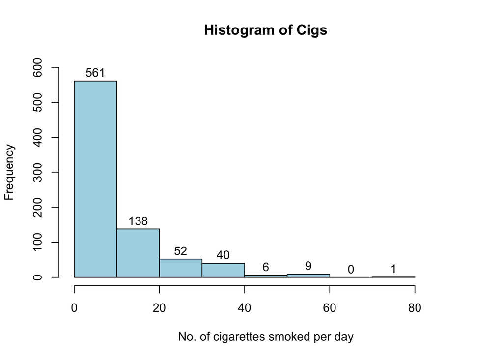

```r
######ii histogram + any outliers?
hist(SK$cigs, main = "Histogram of Cigs", xlab = 'No. of cigarettes smoked per day', col = 'light blue', labels = TRUE, ylim = c(0,600), xlim=c(0,90))
```

```r
######iii 95% confidence level for mean 'cigs'
t <- qt((1-0.025),df =nrow(SK)-1)
deviation <- t*(SK.cigs$sd/sqrt(nrow(SK)))
mean <- SK.cigs$mean
lPI.cigs <- mean - deviation
uPI.cigs <- mean + deviation
cbind(round(lPI.cigs,2), round(uPI.cigs,2))
```

```
##      [,1] [,2]
## [1,] 7.74 9.64
```

Type your answer here. ii. Distribution of cigs is positively skewed. Thus the data is not normally distributed. One outlier where 1 person smokes between 70 to 80 cigarettes per day.  
iii confidence interval: 8.686493 +- 0.948126 –> [7.738367, 9.634619]. As 10 is outside the range of this confidence interval, we cannot conclude that the mean is 10.

**END: YOUR ANSWER**

### Q2.(d) Dashboard for `cigpric` (4 marks)

- 1. Develop the 99% prediction interval for `cigpric`. Explain what the interval tells us.

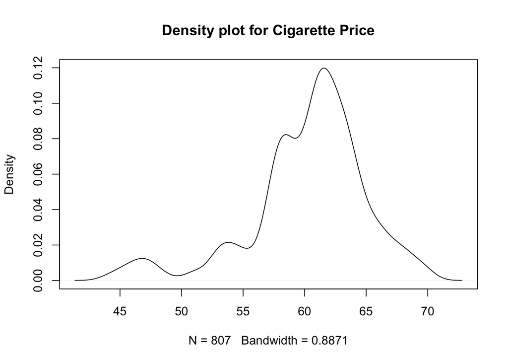

```r
#Check normality
plot(density(SK$cigpric),main="Density plot for Cigarette Price") #slightly left-skewed
```

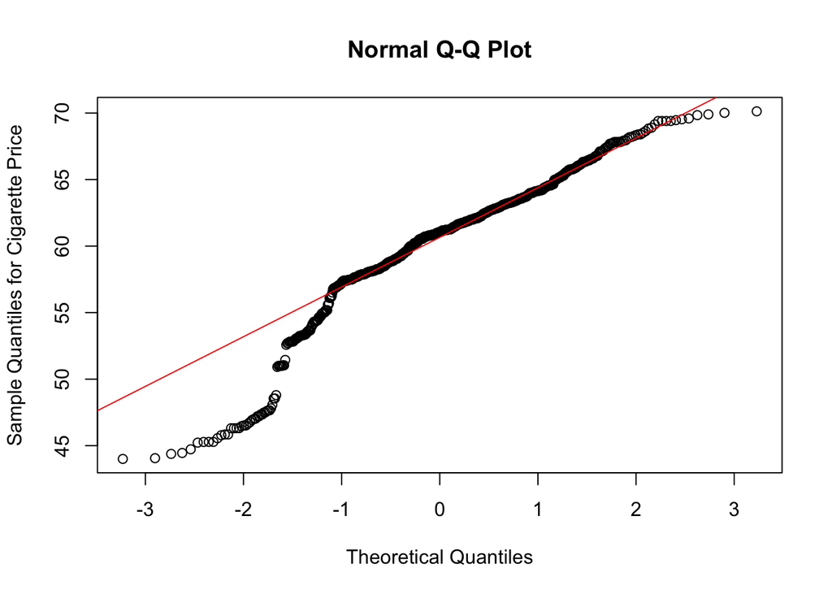

```r
qqnorm(SK$cigpric,ylab="Sample Quantiles for Cigarette Price")
qqline(SK$cigpric,col="red")
```

```r
shapiro.test(SK$cigpric)
```

```
##
##  Shapiro-Wilk normality test
##
## data:  SK$cigpric
## W = 0.9279, p-value < 2.2e-16
```

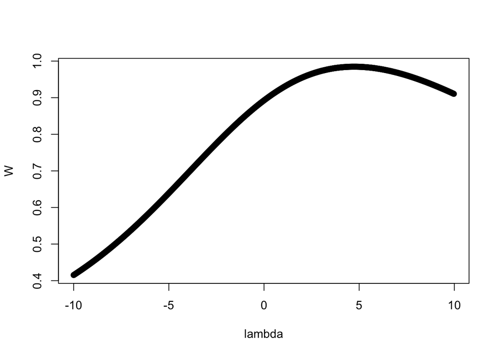

```
##
##     lambda      W Shapiro.p.value
## 585    4.6 0.9846       1.624e-07
##
## if (lambda >  0){TRANS = x ^ lambda}
## if (lambda == 0){TRANS = log(x)}
## if (lambda <  0){TRANS = -1 * x ^ lambda}
```

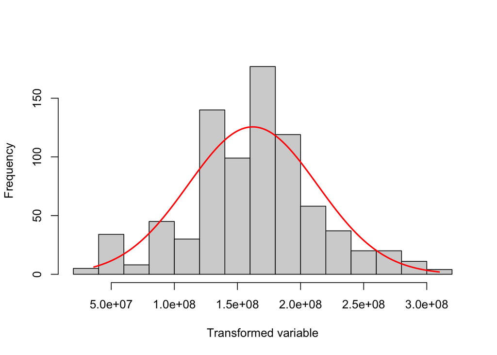

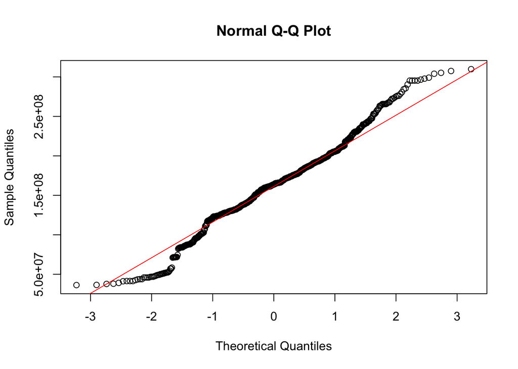

```r
#Based on visual inspection and values from shapiro test, we can infer that the data for cigpric deviates from normality.
SK.cigprict <- transformTukey(SK$cigpric,plotit=TRUE)
```

```r
t <- qt((1-0.005), df = nrow(SK)-1)
sd <- sd(SK.cigprict)
deviation <- t*(sd*sqrt(1+1/nrow(SK)))
mean <- mean(SK.cigprict)
lPI.cigpric <- mean - deviation
uPI.cigpric <- mean + deviation
print(cbind(lPI.cigpric, uPI.cigpric), digit=4)
```

```
##      lPI.cigpric uPI.cigpric
## [1,]    29618772   294590604
```

```r
#reverse transform:
#y = x**lambda --> y = x**4.6 --> x = y**(1/4.6)
lPI.cigpric <- (mean - deviation) ^(1/4.6)
uPI.cigpric <-(mean + deviation)^(1/4.6)
print(cbind(lPI.cigpric, uPI.cigpric), digit=4)
```

```
##      lPI.cigpric uPI.cigpric
## [1,]        42.1       69.36
```

Type your answer here. 99% prediction level: [42.1, 69.36].

**END: YOUR ANSWER**

### Q2.(e) Use the data to test if the mean number of cigarettes smoked per day is higher for individuals who are from states where restaurants have smoking restrictions versus those from states where restaurants do not have smoking restrictions. Conduct the appropriate hypothesis test and explain your conclusion from the results. Be sure to state your H0/H1 clearly, defining any symbols or notations you use in your hypothesis. (4 marks)

```r
#To test H0 : u1<=u0 vs H1: u1>u0 where u1 is the mean number of cigarettes smoked per day for individuals who are from the states where restaurants have smoking restrictions while u0 is the mean number of cigarettes smoked per day..restaurants do not have smoking restrictions

#Two sample test for means with independent samples --> use t-test

t.test(cigs~restaurn, alternative ="less",data=SK)
```

```
##
##  Welch Two Sample t-test
##
## data:  cigs by restaurn
## t = 2.7161, df = 398.48, p-value = 0.9966
## alternative hypothesis: true difference in means between group 0 and group 1 is less than 0
## 95 percent confidence interval:
##      -Inf 4.454742
## sample estimates:
## mean in group 0 mean in group 1
##        9.370066        6.597990
```

```r
#this is because in the test H1 is H1: u0 - u1 <0[u0<u1] and our H1 is H1: u1<u0
```

Type your answer here. As the p-value = 0.9966 > 0.05 at 5% significance level, we have insufficient evidence to reject H0 and thus cannot conclude that the mean number of cigarettes smoked per day is higher for individuals who are from states where restaurants have smoking restrictions versus those from states where restaurants do not have smoking restrictions.

**END: YOUR ANSWER**

### Q2.(f) Use the data to test if the mean number of cigarettes smoked per day varies across people in different age groups. (7 marks)

- 1. Start by creating a variable, called `agegp` which will have 3 values: 1- for age less than 30; 2- for age 30 to 48; 3 - for age greater than 48. This variable defines the three age groups that we will compare in part ii. (1 mark)
- 2. Create a table to display the frequency distribution for `agegp`. (1 mark)
- 3. Conduct the appropriate hypothesis test to assess if the mean number of cigarettes smoked per day is same across people of three age groups. Be sure to state your H0/H1 clearly, defining any symbols or notations you use in your hypothesis, and explain your conclusion from the results.(5 marks)

```r
######i create agegp
SKfi <- SK %>% mutate(agegp = ifelse( age<30, 1 , ifelse(age<49, 2, 3)))

######ii table
SKfii <- SKfi %>% count(agegp)
kable(SKfii, caption = "Frequency distribution for 'agegp'")
```

Frequency distribution for ‘agegp’

| agegp | n |
| --- | --- |
| 1 | 253 |
| 2 | 284 |
| 3 | 270 |

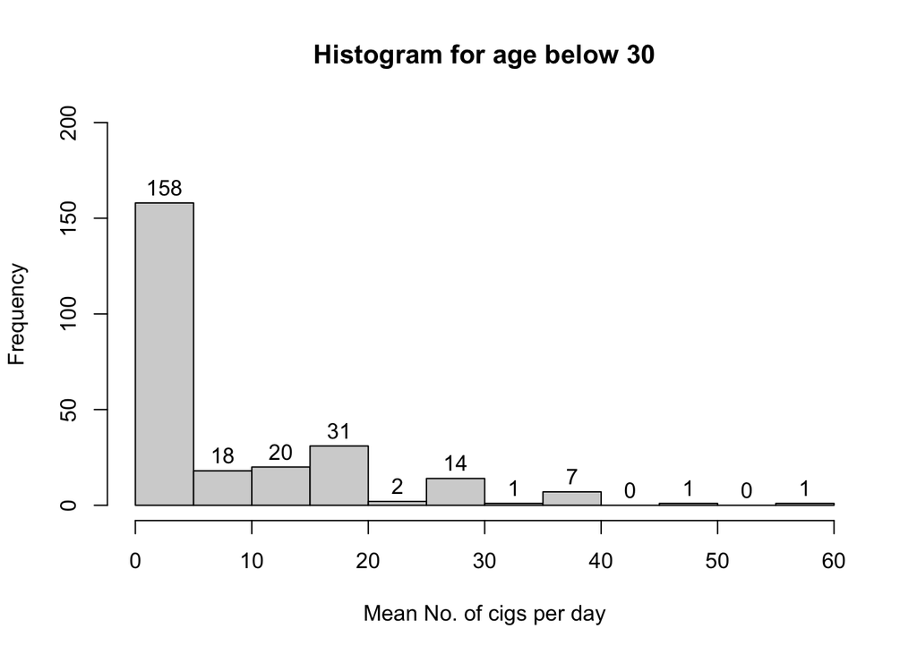

```r
######iii mean cig same across 3 age groups

#More than 2 samples so we use ANOVA  --> but assumption need to be checked

#To test H0: u1 = u2 = u3 vs H1: at least 1 u is different from the others
#u1 is the mean no. of cigs smoked per day by someone in age category 1(<30 ), u2 for age category 2(30-48), u3 for age category3(>48)

###check normality
young <- SKfi %>% filter(agegp == 1)
middle <- SKfi %>% filter(agegp == 2)
old <- SKfi %>% filter(agegp == 3)

#visual inspection - histogram
hist(young$cigs, main= "Histogram for age below 30", xlab="Mean No. of cigs per day", ylim = c(0,200), xlim = c(0,60), labels=TRUE)
```

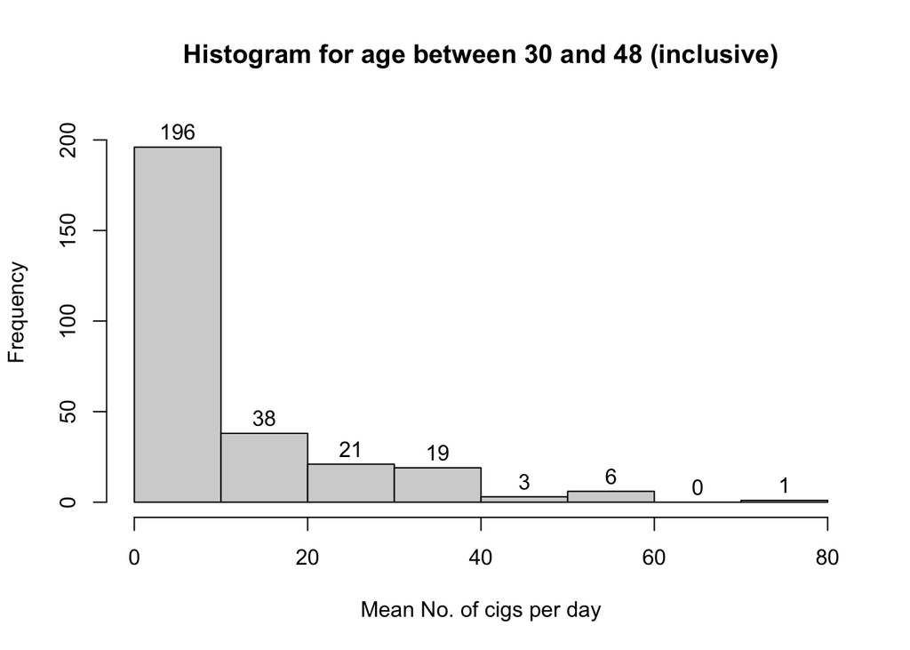

```r
hist(middle$cigs, main= "Histogram for age between 30 and 48 (inclusive)", xlab="Mean No. of cigs per day", ylim = c(0,210), xlim = c(0,80), labels = TRUE)
```

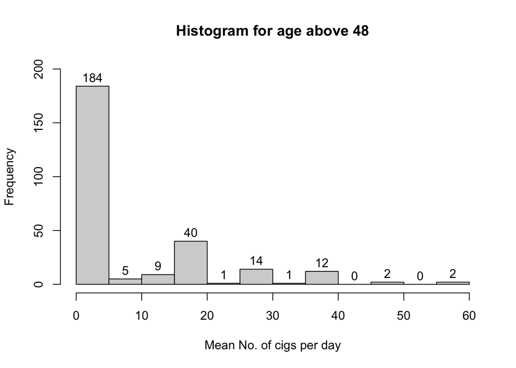

```r
hist(old$cigs, main= "Histogram for age above 48", xlab="Mean No. of cigs per day", ylim = c(0,200), xlim = c(0,60), labels=TRUE)
```

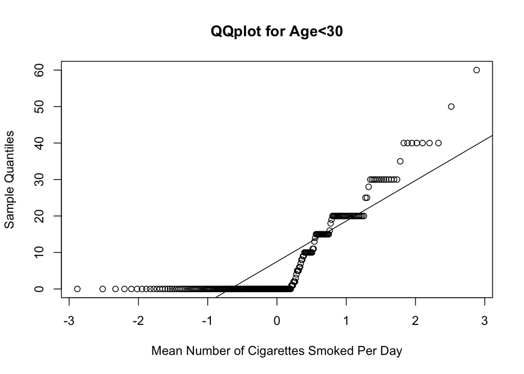

```r
#visual inspection - qqplot
qqnorm(young$cigs, main="QQplot for Age<30", xlab="Mean Number of Cigarettes Smoked Per Day")
qqline(young$cigs)
```

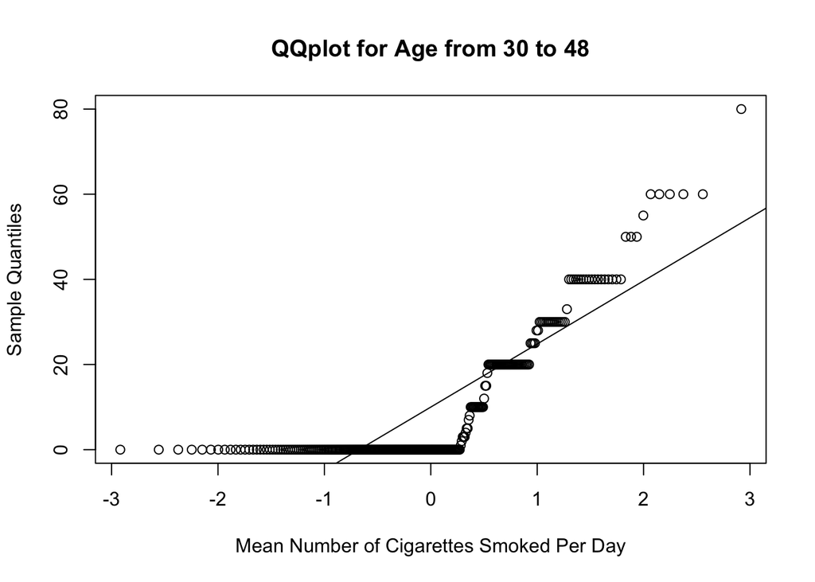

```r
qqnorm(middle$cigs, main="QQplot for Age from 30 to 48", xlab="Mean Number of Cigarettes Smoked Per Day")
qqline(middle$cigs)
```

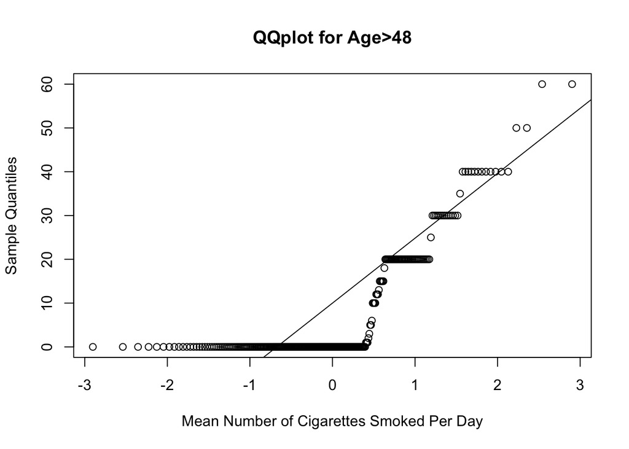

```r
qqnorm(old$cigs, main="QQplot for Age>48", xlab="Mean Number of Cigarettes Smoked Per Day")
qqline(old$cigs)
```

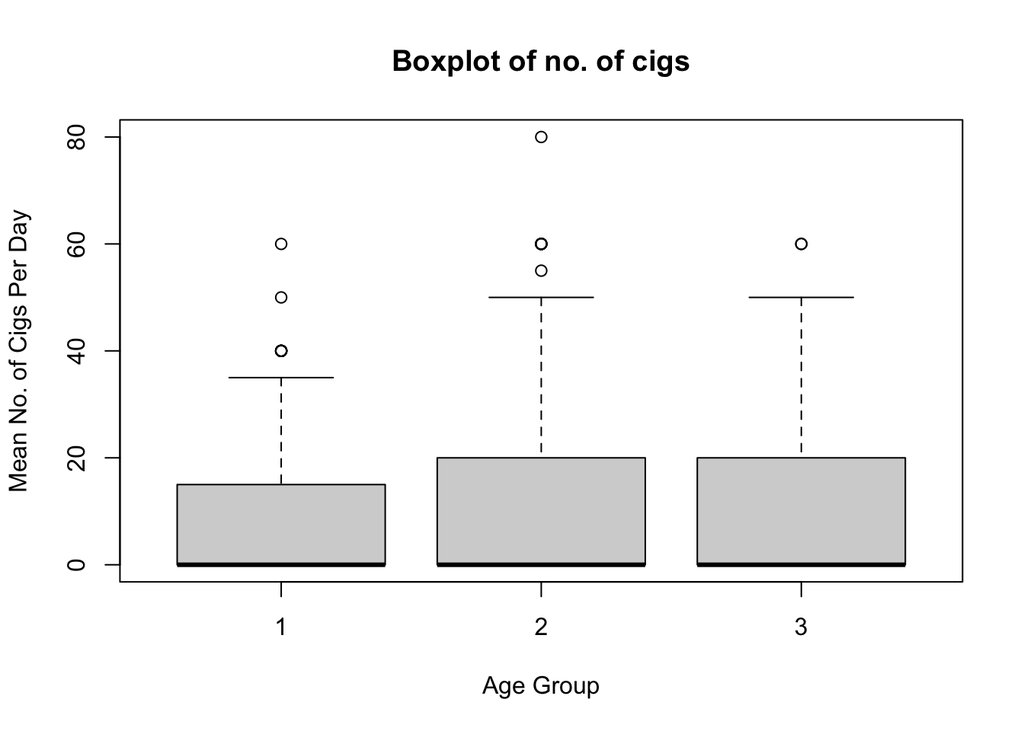

```r
#visual inspection - boxplot
boxplot(SKfi$cigs ~ SKfi$`agegp`, ylab="Mean No. of Cigs Per Day", xlab="Age Group", main = 'Boxplot of no. of cigs')
```

```r
#shapiro wilk test
lapply(list(young,middle,old),function(sa){shapiro.test(sa$cigs)} )
```

```
## [[1]]
##
##  Shapiro-Wilk normality test
##
## data:  sa$cigs
## W = 0.71621, p-value < 2.2e-16
##
##
## [[2]]
##
##  Shapiro-Wilk normality test
##
## data:  sa$cigs
## W = 0.69444, p-value < 2.2e-16
##
##
## [[3]]
##
##  Shapiro-Wilk normality test
##
## data:  sa$cigs
## W = 0.66271, p-value < 2.2e-16
```

```r
#Based on visual inspection and the Shapiro Wilk Test, data is not normally distributed.

###check sample size across age groups
table(SKfi$agegp)
```

```
##
##   1   2   3
## 253 284 270
```

```r
#Sample sizes are not equal. Check if equal variance assumption is met.
fligner.test(cigs ~ agegp, SKfi)
```

```
##
##  Fligner-Killeen test of homogeneity of variances
##
## data:  cigs by agegp
## Fligner-Killeen:med chi-squared = 3.4464, df = 2, p-value = 0.1785
```

```r
#Since p-value=0.1785 >0.05,we cannot reject the assumption that variances for the no. of cigs are equal. Based on this result, we proceed to conduct ANOVA test.

#conduct ANOVA#
SKfi$agegp <- as.factor(SKfi$agegp)
aov.cigs <- aov(SKfi$cigs ~ SKfi$agegp)
summary(aov.cigs)
```

```
##              Df Sum Sq Mean Sq F value Pr(>F)
## SKfi$agegp    2    821   410.7   2.188  0.113
## Residuals   804 150932   187.7
```

```r
TukeyHSD(aov.cigs)
```

```
##   Tukey multiple comparisons of means
##     95% family-wise confidence level
##
## Fit: aov(formula = SKfi$cigs ~ SKfi$agegp)
##
## $`SKfi$agegp`
##           diff        lwr       upr     p adj
## 2-1  2.1911568 -0.5900885 4.9724022 0.1542323
## 3-1  0.1605621 -2.6544501 2.9755744 0.9901602
## 3-2 -2.0305947 -4.7651419 0.7039525 0.1896954
```

**END: YOUR ANSWER**